# Coding Cookbook

## Computing Residuals

Diagnostic graphics used to assess conditions on the stochastic portion of the model depend on residuals and fitted values. In order to obtain the residuals, we augment the original data based on the model constructed using the `obtain_diagnostics()` function. These results must be stored in a dataset. This function cannot be used until you first specify a model so that residuals can be computed.

1. First argument is the model fit (from the full model under the alternative hypothesis if comparing two models).
2. Second argument is the dataset we want to add to.

```r
mtcars.augment = obtain_diagnostics(reg.model, data = mtcars)
```

The result is actually a new dataset which includes various new variables (beginning with period in the name) used to assess a model fit. The variable `.resid` contains the residuals, and the variable `.fitted` contains the fitted values or predicted values. The first few records of this new dataset are shown below:

| mpg | cyl | disp | hp | drat | wt | qsec | vs | am | gear | carb | Gallons_per_Mile | .fitted | .resid |
| --- | --- | --- | --- | --- | --- | --- | --- | --- | --- | --- | --- | --- | --- |
| 21.0 | 6 | 160 | 110 | 3.90 | 2.620 | 16.46 | V Engine | Manual Transmission | 4 | 4 | 0.048 | 23.283 | -2.283 |
| 21.0 | 6 | 160 | 110 | 3.90 | 2.875 | 17.02 | V Engine | Manual Transmission | 4 | 4 | 0.048 | 21.920 | -0.920 |
| 22.8 | 4 | 108 | 93 | 3.85 | 2.320 | 18.61 | Straight Engine | Manual Transmission | 4 | 1 | 0.044 | 24.886 | -2.086 |
| 21.4 | 6 | 258 | 110 | 3.08 | 3.215 | 19.44 | Straight Engine | Automatic Transmission | 3 | 1 | 0.047 | 20.103 | 1.297 |
| 18.7 | 8 | 360 | 175 | 3.15 | 3.440 | 17.02 | V Engine | Automatic Transmission | 3 | 2 | 0.053 | 18.900 | -0.200 |
| 18.1 | 6 | 225 | 105 | 2.76 | 3.460 | 20.22 | Straight Engine | Automatic Transmission | 3 | 1 | 0.055 | 18.793 | -0.693 |

## Diagnostic Plots: Time-Series Plot

If the data is recorded in the order in which it was collected, we can construct a time-series plot of the residuals.

1. Use the augmented dataset (see above) that contains the residuals.
2. Set `y = .resid`.
3. Set `x = seq_along(.resid)` to construct the order of the observations.
4. Set `geom = c("line", "point")` to connect the dots for an better view.

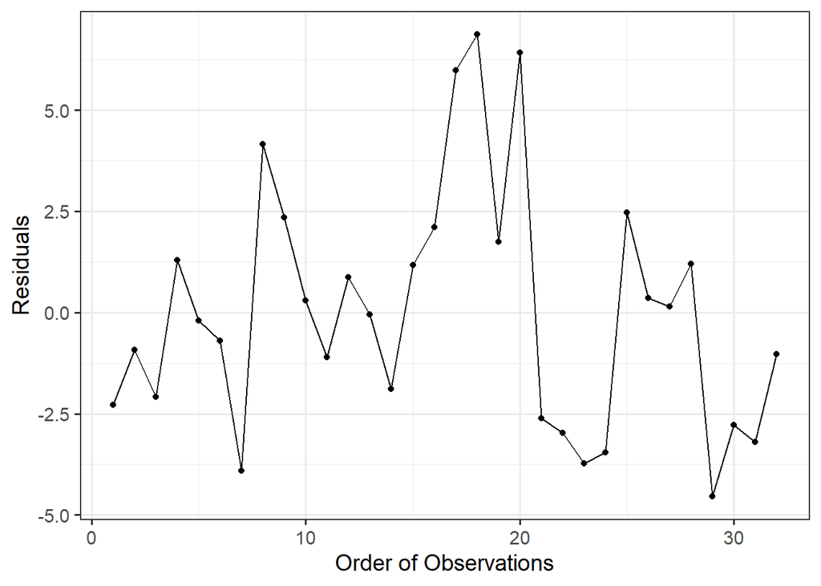

```r
qplot(data = mtcars.augment,
      y = .resid,
      x = seq_along(.resid),
      geom = c("line", "point")) +
  labs(y = "Residuals",
       x = "Order of Observations")
```

The nice thing about this graphic is that the only thing that changes is the dataset from which to pull the residuals.

## Diagnostic Plots: Residual vs. Fitted Values

A plot of the residuals against the fitted values can be helpful for assessing various conditions.

1. Use the augmented dataset (see above) that contains the residuals.
2. Set `y = .resid`.
3. Set `x = .fitted`.
4. Set `geom = "point"`.

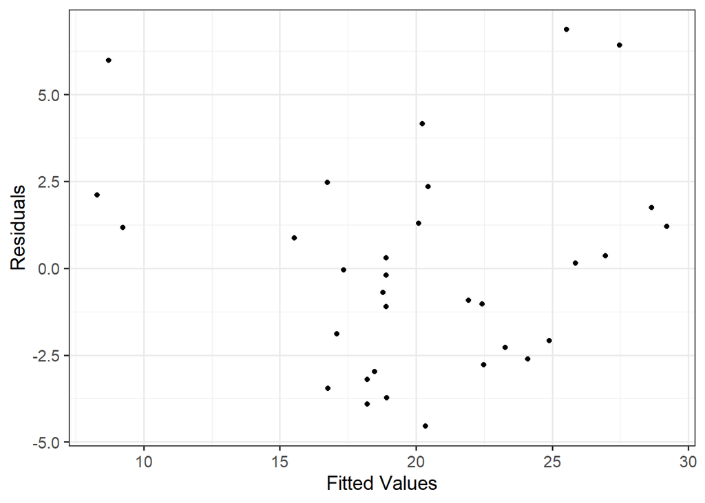

```r
qplot(data = mtcars.augment,
      y = .resid,
      x = .fitted,
      geom = "point") +
  labs(y = "Residuals",
       x = "Fitted Values")
```

It can sometimes be helpful to include a smoother on this graphic. This can be done easily by adjusting the `geom` option.

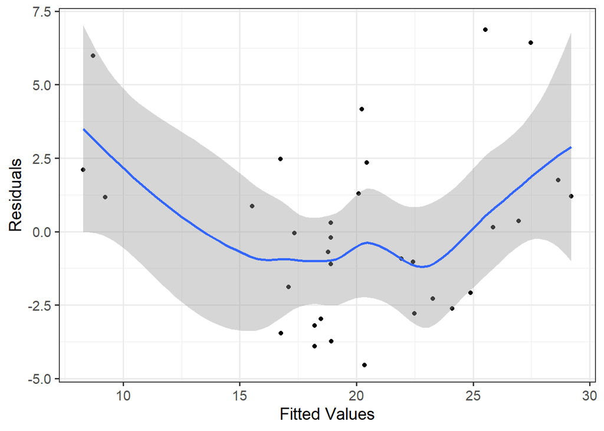

```r
qplot(data = mtcars.augment,
      y = .resid,
      x = .fitted,
      geom = c("point", "smooth")) +
  labs(y = "Residuals",
       x = "Fitted Values")
```

## Diagnostic Plots: Probability Plot

A probability plot, or quanitile-quantile plot (QQ-plot for short) can also be made of the residuals.

1. Use the augmented dataset (see above) that contains the residuals.
2. Set `sample = .resid`.
3. Set `geom = "qq"`.

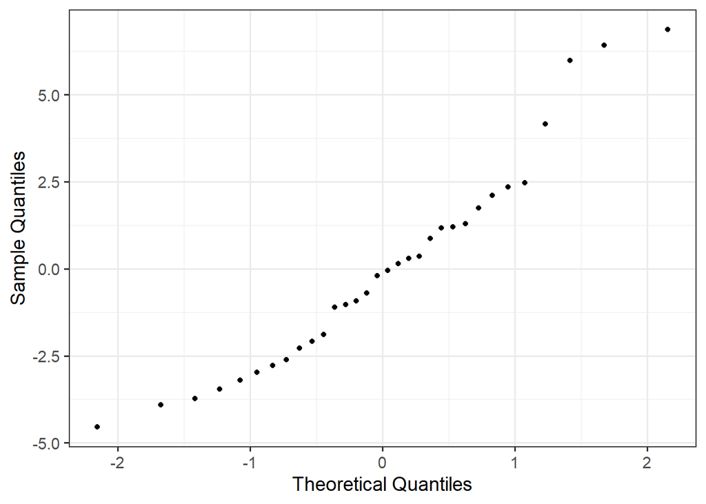

```r
qplot(data = mtcars.augment,
      sample = .resid,
      geom = "qq") +
  labs(x = "Theoretical Quantiles",
       y = "Sample Quantiles")
```

## Estimating the Mean Response

Consider our model for allowing the mean fuel efficiency to depend upon the weight of the vehicle:
$$\text{Unrestricted Model:} \quad (\text{MPG})_i = \beta_0 + \beta_1(\text{Weight})_i + \epsilon_i$$

Suppose we are interested in estimating the average fuel efficiency for a vehicle which weighs 2000 pounds and one which weighs 3000 pounds (keeping in mind that `wt` is specified in 1000’s of pounds). Instead of estimating the parameters of the model, we are interested in estimating the mean response, which is done with `estimate_mean_response()`:

```r
estimate_mean_response(reg.model,
                       confidence.level = 0.95,
                       assume.identically.distributed = TRUE,
                       assume.normality = TRUE,
                       wt = c(2, 3))
```

```
  wt .estimate .standard.error 95% lower 95% upper
1  2  26.59618       0.8678067  24.82389  28.36848
2  3  21.25171       0.5519713  20.12444  22.37899
```

The majority of the arguments for this function are similar to `estimate_parmaeters()`. However, you must also specify the values of the covariates for which to estimate your response. Multiple values are placed in a vector using the `c()` construct.

# ANOVA Models

ANOVA models are extensions of regression model which compare a quantitative response across the levels of a categorical variable. For our purposes, consider comparing the efficiency of vehicles with an automatic transmission to those with a manual transmission. Our model has the following form:

$$\begin{aligned}
(\text{MPG})_i &= \mu_1\mathbb{I}(\text{i-th vehicle has automatic transmission}) \\
&\quad + \mu_2\mathbb{I}(\text{i-th vehicle has manual transmission}) + \epsilon_i
\end{aligned}$$

As with any model, our first step is to specify that model in the computer. Notice that the above model has a parameter for each level of the variable `am` and does not have an intercept. This can be specified as follows:

```r
anova.model = specify_mean_model(mpg ~ am, data = mtcars)
```

As long as the variable on the right-hand-side is a categorical variable, the computer will automatically construct the appropriate indicator functions.

## Computing a P-Value

Comparing two ANOVA models is not different than comparing two regression models. Consider the hypothesis of interest:

$$H_0: \mu_1 = \mu_2 \qquad \text{vs.} \qquad H_1: \mu_1 \neq \mu_2$$

Under the alternative hypothesis, we have an unrestricted model:
$$\begin{aligned}
\text{Unrestricted Model:} \quad (\text{MPG})_i &= \mu_1\mathbb{I}(\text{i-th vehicle has automatic transmission}) \\
&\quad + \mu_2\mathbb{I}(\text{i-th vehicle has manual transmission}) + \epsilon_i
\end{aligned}$$

If the null hypothesis is true, the model for our data generating process would be restricted:
$$\text{Restricted Model:} \quad (\text{MPG})_i = \mu + \epsilon_i$$

where $\mu$ is the overall mean response — the common value of $\mu_1$ and $\mu_2$. In order to construct the p-value we must communicate both models to the computer and then compuare them.

```r
anova.model.h1 = specify_mean_model(mpg ~ am, data = mtcars)
anova.model.h0 = specify_mean_model(mpg ~ 1, data = mtcars)

compare_models(anova.model.h1,
               anova.model.h0,
               assume.identically.distributed = TRUE,
               assume.normality = TRUE)
```

```
            source df       ss        ms statistic      p.value
1 Additional Terms  1 405.1506 405.15059  16.86028 0.0002850207
2            Error 30 720.8966  24.02989        NA           NA
```

The output contains a summary of the comparison between the two models in the form of a classical ANOVA table. Changing the conditions will determine if the p-value is computed via bootstrapping or classical probability theory.

## Computing Residuals

Diagnostic graphics are similar to those in regresion. The one change is that it is often helpful to view the residuals across the groups. This can be done by making a side-by-side boxplot of the residuals from augmented data.

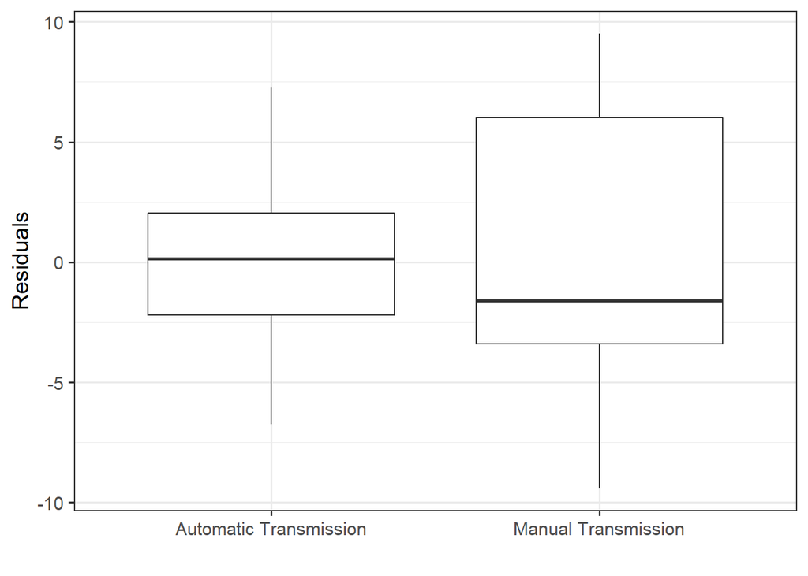

```r
mtcars.augment = obtain_diagnostics(anova.model.h1, data = mtcars)

qplot(data = mtcars.augment,
      y = .resid,
      x = am,
      geom = "boxplot") +
  labs(y = "Residuals",
       x = "")
```

# Frequently Asked Questions

There are some things students run into a lot. Here are some common situations.

## I just want to look at my dataset; how?

The easiest way is to go to the “Environment” tab in RStudio and double-click on the name of the dataset. It will open a spread-sheet like interface for looking at your dataset.

## My variable name has spaces and R does not like it!

Variable names which have spaces in them need to be wrapped in back ticks. Technically, all variable names can be done this way, but it is a requirement when the variable name has spaces. For example, the following is allowed:

```r
mtcars = mtcars %>%
  mutate(`Miles Per Gallon` = mpg)
```

## Why does my code block not have a green arrow?

A code block should be completely separate from surrounding text. So, be sure there is a blank line both before the code block and after it. Usually, this fixes the problem.

## How can I make a caption for my graphic?

In your code chunk, include the `fig.cap` option. For example, a code chunk might look like the following:

````
```{r, fig.cap="Relationship between fuel efficiency and the horsepower of a vehicle."}
qplot(data = mtcars
      x = hp
      y = mpg) +
  labs(x = "Horse Power",
       y = "Miles per Gallon")
```
````

This block would produce the following image (notice caption below image):

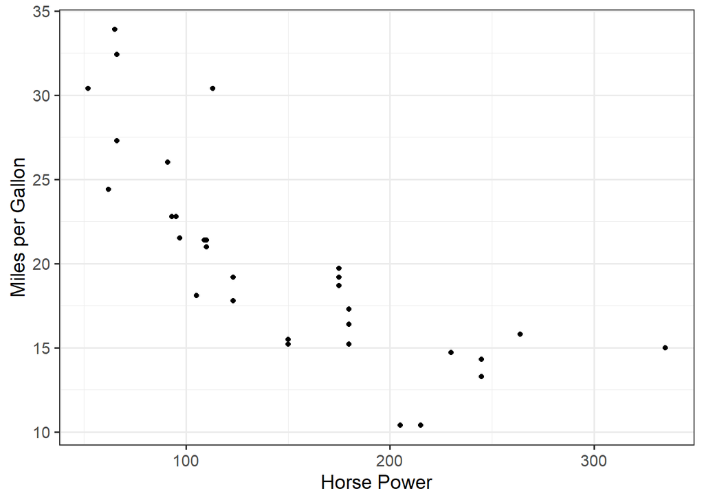

Relationship between fuel efficiency and the horsepower of a vehicle.

An alternative is to add a “title” label:

```r
qplot(data = mtcars,
      x = hp,
      y = mpg) +
  labs(x = "Horse Power",
       y = "Miles per Gallon",
       title = "Relationship between fuel efficiency and horsepower.")
```

## R is not treating my “grouping” variable correctly!

Generally, this happens when your “grouping” variable is a number instead of a phrase. For example, in the `mtcars` dataset, the variable `cyl` takes values 4, 6, or 8. However, R does not know that these values represent groups instead of actual values. In order to get the program to recognize it as a group, rewrite the variable using `factor()`:

```r
mtcars = mtcars %>%
  mutate(cyl = factor(cyl))
```

Now, `cyl` will be treated as a grouping variable. This needs to be done only once and will work for all subsequent graphics and models constructed.

Note: you could also recode the variable manually if you wanted to:

```r
mtcars = mtcars %>%
  mutate(cyl = recode(cyl,
                      `4` = "4 Cylinder",
                      `6` = "6 Cylinder",
                      `8` = "8 Cylinder"))
```

The choice is yours.